# Fraudulent Credit Card Purchases

Data Accessing

- Download the data
- Number of Records and Fields
- Summary Statistics

Exploratory Data Analysis

- Histogram of transactionAmount
- Explorations and Hypotheses
  - At the Cardholder Level
    - Atypical transaction amounts can be fraudulent
    - Several, frequent, transactions can be fraudulent
    - Accounts with histories of fraud should be scrutinized
  - At the Transaction Level
    - Certain types of merchants are more likely to see fraud
    - Fraud tends to be with higher transaction amounts
    - Fraud tends be associated with cards not present at POS
    - No immediate relationship between account ages and expiry dates to fraud
    - Mismatching CVV transactions tend to be fraudulent
  - At the Merchant Level
    - Fraud at a merchant poisons other transactions at the merchant
    - Fraud occurs almost uniformly over franchises

Feature Designing

- Identifying Reversals
- Identifying Multiswipes
- Findings from Reversals and Multiswipes
- Final bits of data wrangling prior to modeling

Models

- Models to Evaluate
- Metric to Optimize
- Results

Future Directions

# Loading Packages

```python
import urllib
import io
import pandas as pd
import numpy as np
import matplotlib.pyplot as plt
from scipy.stats import fisher_exact
from zipfile import ZipFile
import seaborn as sns

from sklearn.model_selection import GridSearchCV, KFold, train_test_split, cross_validate, cross_val_predict
from sklearn.ensemble import  VotingClassifier, RandomForestClassifier, GradientBoostingClassifier
from xgboost import XGBClassifier, plot_importance
from sklearn.metrics import confusion_matrix
from imblearn.under_sampling import RandomUnderSampler

import warnings
warnings.filterwarnings("ignore")
```

# Data Accessing

## a) Download and Load Data

The data is provided as a URL, thus any data scientist or collaborator can access it with an internet connection, rather than relying on a downloaded data set before running this file. The code below downloads the data set in its current state from github. Run the code below to download the data, and load it as a pandas data frame. Some entries are empty, which we replace with NaN values. The dataframe is stored as `data`.

```python
# download current snapshot of the data
url = [masked per original owners request]
zipfile = ZipFile(io.BytesIO(urllib.request.urlopen(url).read()))
zipfile.extractall(path='.')

# data is saved as transactions.txt. parse it as a json
data = pd.read_json('transactions.txt', lines='transactions.txt')

# replace empty records with NaN
data = data.replace(r'^\s*$', np.nan, regex=True)
```

## b) Number of Record and Fields

There are 786,363 transactions recorded. Each transaction is represented by 29 features, from account numbers to merchant names and card information. One of the features tells us if the transaction is fradulent.

```python
print(data.shape)
print(data.columns)
```

```
(786363, 29)
Index(['accountNumber', 'customerId', 'creditLimit', 'availableMoney',
       'transactionDateTime', 'transactionAmount', 'merchantName',
       'acqCountry', 'merchantCountryCode', 'posEntryMode', 'posConditionCode',
       'merchantCategoryCode', 'currentExpDate', 'accountOpenDate',
       'dateOfLastAddressChange', 'cardCVV', 'enteredCVV', 'cardLast4Digits',
       'transactionType', 'echoBuffer', 'currentBalance', 'merchantCity',
       'merchantState', 'merchantZip', 'cardPresent', 'posOnPremises',
       'recurringAuthInd', 'expirationDateKeyInMatch', 'isFraud'],
      dtype='object')
```

## c) Summary Statistics

There is some data preprocessing we need to do. For example, dates should be converted to datetime objects for more detailed summary statistics and provide opportunities for time series analysis for informed business decisions. The four features that can be converted to datetime objects are

- `transactionDateTime`: date and time of the transaction
- `currentExpDate`: expiration date of the card
- `accountOpenDate`: date account was openned
- `dateOfLastAddressChange`: last date when address changed

Additionally, we convert the following features to objects:

- `accountNumber`: This is just an ID to identify the account
- `customerId`: This is just an ID to identify the customer
- `cardCVV`: This is a 3 digit code that functions as a passphrase
- `enteredCVV`: Like `cardCVV`
- `cardLast4Digits`: This is simply the last 4 digits of a credit card number

We treat the above as objects rather than numerical values because there is no concept of ordering. For example, a CVV of 301 is not considered greater than a CVV of 300, despite the CVV is represented numerically.

We address some findings from the data summaries, below.

```python
# converting the date columns to datetime objects
data['transactionDateTime'] = pd.to_datetime(data['transactionDateTime'],format='%Y-%m-%dT%H:%M:%S')
data['currentExpDate'] = pd.to_datetime(data['currentExpDate'], format='%m/%Y')
data['accountOpenDate'] = pd.to_datetime(data['accountOpenDate'], format='%Y-%m-%d')
data['dateOfLastAddressChange'] = pd.to_datetime(data['dateOfLastAddressChange'], format='%Y-%m-%d')

# convert features to objects
data['accountNumber'] = data['accountNumber'].astype(object)
data['customerId'] = data['customerId'].astype(object)
data['cardCVV'] = data['cardCVV'].astype(object)
data['enteredCVV'] = data['enteredCVV'].astype(object)
data['cardLast4Digits'] = data['cardLast4Digits'].astype(object)
```

```python
# datatype for each column
dtypes = data.dtypes
dtypes.name = 'data type'

# null counts and percentages of each column
null_counts = data.isnull().sum()
null_counts.name = 'null counts'
null_percents = (data.isnull().mean()*100).round(2)
null_percents.name = 'null percentages (%)'

# unique counts
unique_data = data.nunique()
unique_data.name = 'unique'

# create summary statistic data set
# remove quantile data for succinctness
summary_data = data.describe(include='all')#, datetime_is_numeric=True)
summary_data = summary_data.drop(['unique', 'count', 'freq', 'std', '25%', '75%', 'top'], axis=0)
summary_data = summary_data.T

# add all summary stats together, and sort by dtype and null counts
summary_data = pd.concat([dtypes, null_counts, null_percents, unique_data, summary_data], axis=1)
summary_data = summary_data.sort_values(['data type', 'null counts'], ascending=True)

summary_data
```

|  | data type | null counts | null percentages (%) | unique | mean | min | 50% | max |
| --- | --- | --- | --- | --- | --- | --- | --- | --- |
| creditLimit | int64 | 0 | 0.00 | 10 | 10759.464459 | 250.0 | 7500.0 | 50000.0 |
| availableMoney | float64 | 0 | 0.00 | 521915 | 6250.725369 | -1005.63 | 3184.86 | 50000.0 |
| transactionAmount | float64 | 0 | 0.00 | 66038 | 136.985791 | 0.0 | 87.9 | 2011.54 |
| currentBalance | float64 | 0 | 0.00 | 487318 | 4508.739089 | 0.0 | 2451.76 | 47498.81 |
| echoBuffer | float64 | 786363 | 100.00 | 0 | NaN | NaN | NaN | NaN |
| merchantCity | float64 | 786363 | 100.00 | 0 | NaN | NaN | NaN | NaN |
| merchantState | float64 | 786363 | 100.00 | 0 | NaN | NaN | NaN | NaN |
| merchantZip | float64 | 786363 | 100.00 | 0 | NaN | NaN | NaN | NaN |
| posOnPremises | float64 | 786363 | 100.00 | 0 | NaN | NaN | NaN | NaN |
| recurringAuthInd | float64 | 786363 | 100.00 | 0 | NaN | NaN | NaN | NaN |
| transactionDateTime | datetime64[ns] | 0 | 0.00 | 776637 | 2016-07-06 01:58:58.395681536 | 2016-01-01 00:01:02 | 2016-07-08 05:03:57 | 2016-12-30 23:59:45 |
| currentExpDate | datetime64[ns] | 0 | 0.00 | 165 | 2026-09-25 23:50:42.724542720 | 2019-12-01 00:00:00 | 2026-10-01 00:00:00 | 2033-08-01 00:00:00 |
| accountOpenDate | datetime64[ns] | 0 | 0.00 | 1820 | 2014-02-03 01:11:17.352825856 | 1989-08-22 00:00:00 | 2014-09-05 00:00:00 | 2015-12-31 00:00:00 |
| dateOfLastAddressChange | datetime64[ns] | 0 | 0.00 | 2184 | 2015-04-14 06:46:41.127723520 | 1989-08-22 00:00:00 | 2016-01-13 00:00:00 | 2016-12-30 00:00:00 |
| cardPresent | bool | 0 | 0.00 | 2 | NaN | NaN | NaN | NaN |
| expirationDateKeyInMatch | bool | 0 | 0.00 | 2 | NaN | NaN | NaN | NaN |
| isFraud | bool | 0 | 0.00 | 2 | NaN | NaN | NaN | NaN |
| accountNumber | object | 0 | 0.00 | 5000 | NaN | NaN | NaN | NaN |
| customerId | object | 0 | 0.00 | 5000 | NaN | NaN | NaN | NaN |
| merchantName | object | 0 | 0.00 | 2490 | NaN | NaN | NaN | NaN |
| merchantCategoryCode | object | 0 | 0.00 | 19 | NaN | NaN | NaN | NaN |
| cardCVV | object | 0 | 0.00 | 899 | NaN | NaN | NaN | NaN |
| enteredCVV | object | 0 | 0.00 | 976 | NaN | NaN | NaN | NaN |
| cardLast4Digits | object | 0 | 0.00 | 5245 | NaN | NaN | NaN | NaN |
| posConditionCode | object | 409 | 0.05 | 3 | NaN | NaN | NaN | NaN |
| transactionType | object | 698 | 0.09 | 3 | NaN | NaN | NaN | NaN |
| merchantCountryCode | object | 724 | 0.09 | 4 | NaN | NaN | NaN | NaN |
| posEntryMode | object | 4054 | 0.52 | 5 | NaN | NaN | NaN | NaN |
| acqCountry | object | 4562 | 0.58 | 4 | NaN | NaN | NaN | NaN |

```python
# dropping columns that are completely NaN
modified_data = data
modified_data.dropna(axis=1, how='all', inplace=True)

# check that accountNumber and customerId are equal. drop one if equal
if np.all(modified_data['accountNumber'] == modified_data['customerId']):
    modified_data = modified_data.drop(columns=['customerId'])

# less than 1% of the entries are different
count = 0
for k, bb in enumerate(modified_data['merchantCountryCode'] == modified_data['acqCountry']):
    if not bb:
        count += 1

print(count / modified_data.shape[0])
modified_data = modified_data.drop(columns=['acqCountry'])

modified_data['matchingCVV'] = modified_data['cardCVV'] == modified_data['enteredCVV']

modified_data.shape
```

```
0.005890409391082744
```

```
(786363, 22)
```

Less than 1% of the transactions happen where `acqCountry` is not the same as the `merchantCountryCode`. We can remove `acqCountry` on the basis that has more missing values. After removing empty columns, and adding a column for checking if CVV is matching, we now have 22 features including `isFraud`.

# Exploratory Data Analysis

## a) Histograms of `transactionAmount`

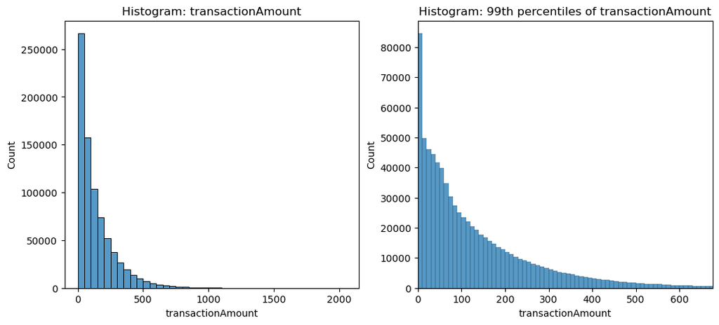

```python
fig, axs = plt.subplots(ncols=2)
fig.set_size_inches(12, 5)
sns.histplot(modified_data['transactionAmount'], binwidth=50, stat='count', ax=axs[0])
sns.histplot(modified_data['transactionAmount'], binwidth=10, stat='count', ax=axs[1])
axs[1].set_xlim(0, modified_data['transactionAmount'].quantile(0.99))
axs[0].set_title('Histogram: transactionAmount')
axs[1].set_title('Histogram: 99th percentiles of transactionAmount')
```

We can see that the vast majority of transactions are less than $400. In fact, the most frequent (mode) value of transactions is within $0 to $10.

## b) Exploratory Analyses and Hypotheses

We are interested in uncovering structure that can help us identify fraudulent transactions. This can also serve as a feature engineering step if we discover interesting features to create. We propose to view the data set in three different manners. First, we look at the data from the account level, where we can examine transactions within accounts and observe if any transactions may be out of the ordinary for the account in question. We also explore transaction level data, where we examine qualities of transactions that may be indicative of fraud. Finally, we study how the store data is organized, and if there is any relationship between merchants and fraud.

Before we explore transaction and account level data, first, we should explore class imbalance. Naturally, we would expect fraud to be a rarer occurence in a compliant bank.

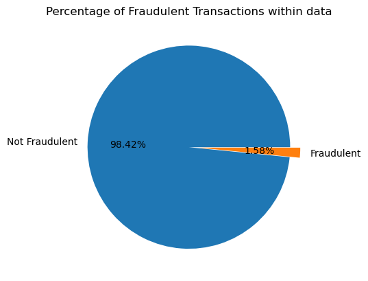

```python
fraud_count = modified_data['isFraud'].value_counts()
keys = ['Not Fraudulent', 'Fraudulent']
plt.pie(fraud_count, labels = keys, explode=[0, 0.1], autopct='%.2f%%')
plt.title('Percentage of Fraudulent Transactions within data')
plt.show()
```

We can see that the data set has a significant class imbalance. About 1.6% of the transactions are acutally fraudulent, while 98.4% of transactions are legitimate. A naive classifier would be correct 98.4% of the time, just be labelling everything as not fraudulent. Of course, such a model would not be very useful.

### Account Level Explorations

We hypothesize the following. For a given account:

- If an account makes a transaction that is significantly different from its previous non-fraudulent transaction amounts, it may be fraudulent.
- If multiple and frequent transactions are made within a short time period, the account should be investigated
- If an account is susceptible to fraud, as measured by the cumulative fraud rate up to the time of each transaction, then most recent transaction should be investigated.

#### i) Transaction amounts that differ from previous amounts might be fraudulent

If an account typically makes small transaction amounts, a transaction of a large amount could be fraudulent, since it is not ordinary for that account. However, if an account typically makes large purchases, a sudden purchase of a low amount may not be fraudulent. We explore this hypothesis below.

We consider a moving median over a quarterly basis, that is, we track the deviation of each transaction from the median of transaction amounts for the last 91 days prior to each transaction. To do so, we take each account, and evaluate the difference between a transaction amount, and its moving median with a 91 day look back. Then we examine how this difference compares between fraudulent and non-fraudulent transactions.

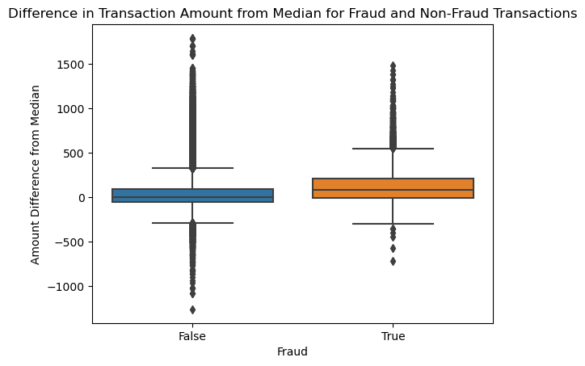

```
isFraud
False    -1.68
True     81.35
Name: difference_moving_median, dtype: float64
```

```python
# for each account, calculate a moving median (more robust than average). window size 91, quarterly
account_grouped = modified_data.groupby('accountNumber')
rolling_median = account_grouped['transactionAmount']
rolling_median = rolling_median.apply(lambda x: x.shift(1).rolling(window=91, min_periods=0).median())
rolling_median = rolling_median.reset_index(0,drop=True)
modified_data['difference_moving_median'] = modified_data['transactionAmount'] - rolling_median

sns.boxplot(x=modified_data['isFraud'], y=modified_data['difference_moving_median'])
plt.title('Difference in Transaction Amount from Median for Fraud and Non-Fraud Transactions')
plt.xlabel('Fraud')
plt.ylabel('Amount Difference from Median')
plt.show()

print(modified_data.groupby('isFraud')['difference_moving_median'].median())
```

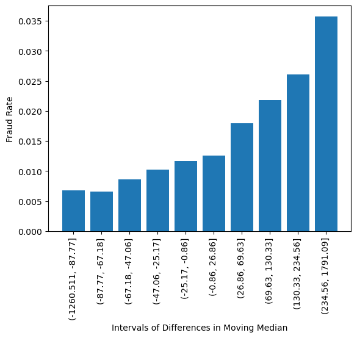

```python
# bin the differenced transaction amounts, and identify fraud within each bin
binned_diff = pd.qcut(modified_data['difference_moving_median'], 10,retbins=True)
diff_data = modified_data.groupby(binned_diff[0])['isFraud'].agg([('isFraud','mean'),('accountNumber','count')])
diff_data = diff_data.reset_index(drop=False)
diff_data = diff_data.rename(columns={'transactionAmount': 'difference amount', 'isFraud': 'fraud percentage'})
plt.bar(diff_data['difference_moving_median'].astype(str), diff_data['fraud percentage'])
plt.xlabel('Intervals of Differences in Moving Median')
plt.ylabel('Fraud Rate')
plt.xticks(rotation=90)
plt.show()
```

Our hypothesis that large transaction amounts that differ from the usual for an account, is more likely to be fraudulent, is confirmed by the barplots. In particular, transaction amounts that are much larger than usual, by at least $234 dollars more, are three times more likely to be fraudulent.

Conversely, transactions that are smaller than the account's ordinary, tend to not be more fraudulent.

#### ii) If multiple and frequent transactions are made within a short time period, the account should be investigated

Typical healthy acconuts would not make several transaction in a short period of time. We define a short period of time to be a minute. We mark all transactions that occur within 1 minute of the previous transaction as transactions occuring in a short period of time, and evaluate how many of them are fraudulent.

The intuition here is that some forms of fraud will repeatedly make transactions within a short (within seconds) period of time. To evaluate this, we take the time difference between each transaction after ordering it by account number and transaction date time. We flag a transaction a "short period" if the time difference is less than 1 minute. Then we evaluate the rate of fraudulent transactions in "short period" transactions and normal transactions.

```
[]
```

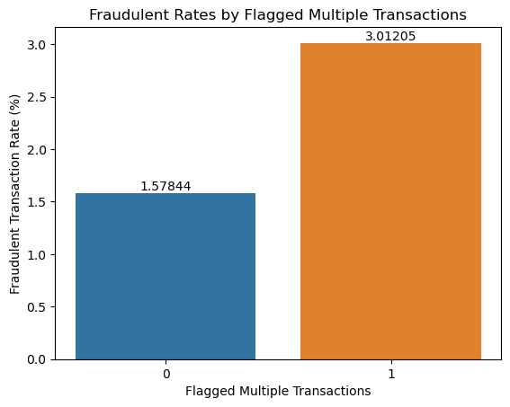

```python
time_window = pd.Timedelta(minutes=1)
# calculate time since last transaction and time until next transaction
modified_data['time_since_prev_transaction'] = modified_data.groupby('accountNumber')['transactionDateTime'].diff()
modified_data['time_until_next_transaction'] = modified_data.groupby('accountNumber')['transactionDateTime'].diff(periods=-1).abs()

flag_multiple_transactions = ((modified_data['time_since_prev_transaction'] <= time_window) &
                              (modified_data['time_until_next_transaction'] <= time_window)).astype(int)

multiple_transactions_df = modified_data.groupby(flag_multiple_transactions)['isFraud']
multiple_transactions_df = multiple_transactions_df.agg([("isFraud", "mean"), ("count", "count")])
multiple_transactions_df['isFraud'] = multiple_transactions_df['isFraud'] * 100

# Barplot of Flagged Multiple Transaction against isFraud
ax = sns.barplot(x=multiple_transactions_df.index, y=multiple_transactions_df.isFraud)
plt.title('Fraudulent Rates by Flagged Multiple Transactions')
plt.xlabel('Flagged Multiple Transactions')
plt.ylabel('Fraudulent Transaction Rate (%)')
plt.bar_label(ax.containers[0])
plt.plot()
```

Based on the analysis, it appears that multiple transactions happening within a 1-minute time period could indicate fraudulent activity. The fraudulent rate of multiple transactions was found to be about 2 times higher compared to transactions that did not meet this time period constraint. Hence, incorporating this feature into our fraud detection system could be useful in detecting fraudulent transactions.

#### iii) Accounts with high cumulative fraud rates, up to the current transaction, tend to have fraudulent transactions again.

An account that is typically involved in fraud will likely be involved in future fraud. Either the account is a popular target for fraud, or it is actively commiting fraud. Regardless, we can implement this by taking each account, and sorting their transactions by time. Then calculate a cumulative fraud rate for each transaction. When we plot the cumulative fraud rate against whether or not the transaction was fraudulent, we would expect to see a higher fraudulent rate for accounts that have a history of fraud - if our hypothesis is supported by the data.

We evaluate this by taking a cumulative sum of fraudulent transactions for each account, as we iterate down a time ordered list of the account's transactions.

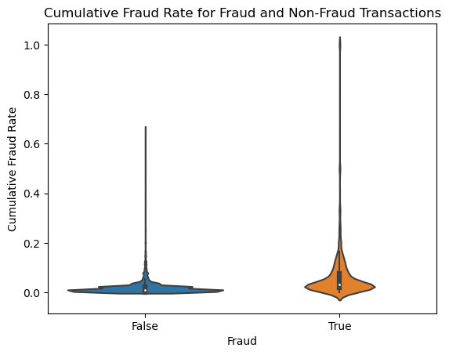

```python
# sort data by accountNumber and transactionDateTime
modified_data = modified_data.sort_values(['accountNumber', 'transactionDateTime'])

# per account, calculate the cumulative sum of fraud up to a current transaction, and the same for number of transactions
cumulative_fraud_count = modified_data.groupby('accountNumber')['isFraud'].cumsum()
cumulative_count = modified_data.groupby('accountNumber')['isFraud'].cumcount() + 1

# calculate the cumulative fraud rate up until the current transaction
cumulative_fraud_rate = cumulative_fraud_count / cumulative_count
modified_data['cumulative_fraud'] = cumulative_fraud_rate
# create a boxplot to visualize the difference in amount for fraud and non-fraud transactions
sns.violinplot(x=modified_data['isFraud'], y=cumulative_fraud_rate)
plt.title('Cumulative Fraud Rate for Fraud and Non-Fraud Transactions')
plt.xlabel('Fraud')
plt.ylabel('Cumulative Fraud Rate')
plt.show()
```

We do see a marked difference in cumulative fraud rates. Fraudulent transactions are more likely to belong to accounts that have a history of fraudulent transactions. We note that this feature may be useful in our predictive model, but when a new account is added, our predictive model may yield false negatives, since we are cannot to keep track of a cumulative sum of fraudulent transactions on a brand new account - this is an unmeasurable event. Nonetheless, this finding can inform future feature engineering and data collection initiatives.

### Transaction Level Explorations

Transaction level explorations tell us what qualities in a transaction make it more likely to be fraudulent.

We propose a few relationships that might be related to fraudulent transactions:

- Relationship of fraud to merchant codes and transaction types: Are transactions with certain merchants common targets for fraud?
- Relationship of fraud to transaction amounts: Are transactions typically high value or low valued in fraud?
- Relationship of fraud to binary variables such as whether or not a card is present, or expiration date matches: Is a card being present associate whether or not a transaction is fraudulent?
- Relationship of fraud to elapsed times: We have time variables on expirations, account opennings, and address changes. Does fraud depend on the ages of accounts, or how close they are to expiry, or if a recent address change leads to more frequent fraud?
- Relationship of fraud to previous flagged cards or incorrectly entered CVV numbers: Do cards that have previously been involved with fraudulent transactions show up again? Do cards with incorrectly entered CVV numbers tend to be more fraudulent?

#### i) Fraud versus merchant codes and transaction types

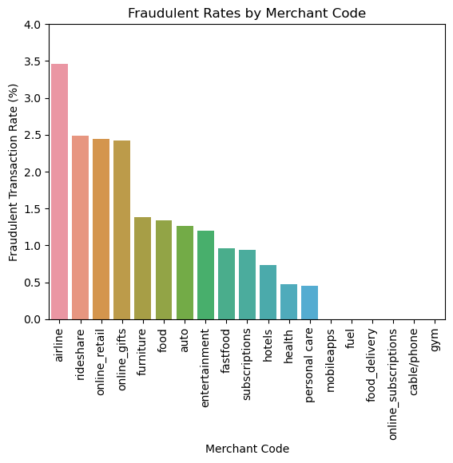

```python
#percentage of fraud transactions by each of the categorical/binary variables of interest
data_by_posMode = modified_data.groupby('posEntryMode')['isFraud'].agg([("isFraud", "mean"), ("count", "count")])
data_by_posMode['isFraud']*=100

data_by_posCondition = modified_data.groupby('posConditionCode')['isFraud'].agg([("isFraud", "mean"), ("count", "count")])
data_by_posCondition['isFraud']*=100
data_by_posCondition = data_by_posCondition.sort_values(by='isFraud',ascending=False)

data_by_merchantCode = modified_data.groupby('merchantCategoryCode')['isFraud'].agg([("isFraud", "mean"), ("count", "count")])
data_by_merchantCode['isFraud']*=100
data_by_merchantCode = data_by_merchantCode.sort_values(by='isFraud',ascending=False)

data_by_transactionType = modified_data.groupby('transactionType')['isFraud'].agg([("isFraud", "mean"), ("count", "count")])
data_by_transactionType['isFraud']*=100

data_by_countryCode = modified_data.groupby('merchantCountryCode')['isFraud'].agg([("isFraud", "mean"), ("count", "count")])
data_by_countryCode['isFraud']*=100

# Barplot of posEntryMode against isFraud
sns.barplot(x=data_by_merchantCode.index, y=data_by_merchantCode.isFraud)
plt.title('Fraudulent Rates by Merchant Code')
plt.xlabel('Merchant Code')
plt.ylabel('Fraudulent Transaction Rate (%)')
plt.ylim((0, 4))
plt.xticks(rotation=90)
plt.show()
```

It is interesting that airline merchants take the largest share of fraudulent transactions in this data set, by almost 1 percentage point higher than the next most commom, rideshares. However, we are curious about what types of transactions that occur at these places tend to be fraudulent, address verifications, purchases, or reversals?

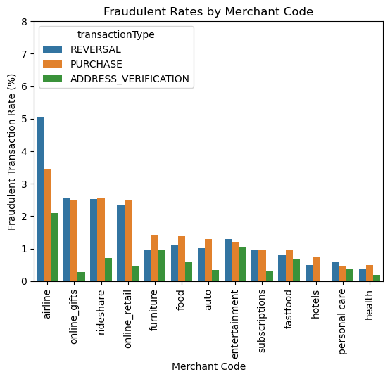

```python
merchants_and_types = modified_data.groupby(['merchantCategoryCode','transactionType'])['isFraud'].agg(
    [("isFraud", "mean"), ("count", "count")]).reset_index()
merchants_and_types['isFraud']*=100
merchants_and_types = merchants_and_types.sort_values(by='isFraud',ascending=False)
merchants_and_types = merchants_and_types[merchants_and_types.isFraud > 0]

# Barplot of posEntryMode against isFraud
sns.barplot(x=merchants_and_types.merchantCategoryCode, y=merchants_and_types.isFraud, hue=merchants_and_types.transactionType)
plt.title('Fraudulent Rates by Merchant Code')
plt.xlabel('Merchant Code')
plt.ylabel('Fraudulent Transaction Rate (%)')
plt.ylim((0, 8))
plt.xticks(rotation=90)
plt.show()
```

The analysis shows that fraud risk varies depending on the type of business and the kind of transaction. For instance, airline ticket reversals are much more likely to be fraudulent, and online gift merchants performing address verifications are less likely to be fraudulent. These features may be helpful in determining fraud.

#### ii) Fraud versus transaction amount

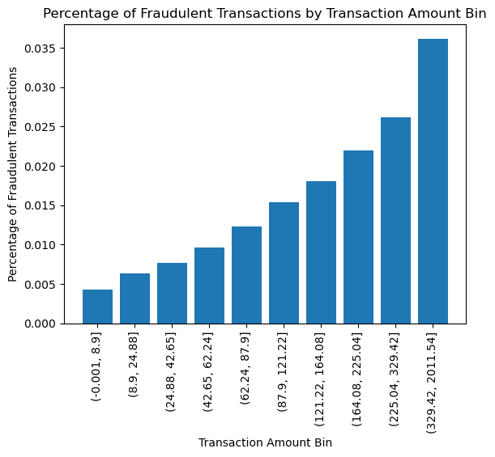

```python
# binning transactionAmount
binned_amount = pd.qcut(modified_data['transactionAmount'],10,retbins=True)
# finding percentage of fraud cases in each bin
fraud_by_amount = modified_data.groupby(binned_amount[0])['isFraud'].agg([('isFraud','mean'),('accountNumber','count')])
fraud_by_amount = fraud_by_amount.reset_index(drop=False)
plt.bar(fraud_by_amount['transactionAmount'].astype(str), fraud_by_amount['isFraud'])
plt.title('Percentage of Fraudulent Transactions by Transaction Amount Bin')
plt.xlabel('Transaction Amount Bin')
plt.ylabel('Percentage of Fraudulent Transactions')
plt.xticks(rotation=90)
plt.show()
```

This plot shows how fraud rates increase as the transaction amount is larger. Larger transaction amounts tend to be more likely to be fraudulent compared to smaller transactions.

#### iii) Fraud versus Binary Data

```python
cont_table_card_present = pd.crosstab(modified_data['isFraud'], modified_data['cardPresent'])
cont_table_card_present_percent = (cont_table_card_present.T/cont_table_card_present.sum(axis=1)).T
print(fisher_exact(cont_table_card_present))
cont_table_card_present_percent
```

```
SignificanceResult(statistic=0.4683985131660093, pvalue=0.0)
```

| cardPresent isFraud | False | True |
| --- | --- | --- |
| False | 0.548531 | 0.451469 |
| True | 0.721752 | 0.278248 |

```python
cont_table_expiration = pd.crosstab(modified_data['isFraud'], modified_data['expirationDateKeyInMatch'])
cont_table_expiration_percent = (cont_table_expiration.T/cont_table_expiration.sum(axis=1)).T
print(fisher_exact(cont_table_expiration))
cont_table_expiration_percent
```

```
SignificanceResult(statistic=0.786460052034577, pvalue=0.45608412390906583)
```

| expirationDateKeyInMatch isFraud | False | True |
| --- | --- | --- |
| False | 0.998669 | 0.001331 |
| True | 0.998953 | 0.001047 |

#### iv) Fraud versus Time Variables

We can investigated the potential link between fraudulent transactions and various time-based factors. These factors include: Time elapsed since:

- Last address change
- Account opening
- Card expiration

To explore this connection, we calculate the following durations based on the transaction date and relevant date variables in the dataset:

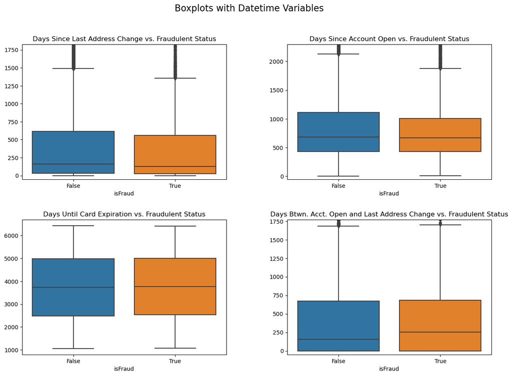

```python
time_since_address = (modified_data['transactionDateTime'] - modified_data['dateOfLastAddressChange']).dt.total_seconds() / (24 * 3600)
time_since_open = (modified_data['transactionDateTime'] - modified_data['accountOpenDate']).dt.total_seconds() / (24 * 3600)
time_til_expire = (modified_data['currentExpDate'] - modified_data['transactionDateTime']).dt.total_seconds() / (24 * 3600)
time_btwn_change_open = (modified_data['dateOfLastAddressChange'] - modified_data['accountOpenDate']).dt.total_seconds() / (24 * 3600)

modified_data['time_since_address'] = time_since_address
modified_data['time_since_open'] = time_since_open
modified_data['time_til_expire'] = time_til_expire
modified_data['time_btwn_change_open'] = time_btwn_change_open

fig, axes = plt.subplots(nrows=2, ncols=2, figsize=(15,10))
sns.boxplot(x=modified_data.isFraud, y=time_since_address, ax=axes[0, 0])
sns.boxplot(x=modified_data.isFraud, y=time_since_open, ax=axes[0, 1])
sns.boxplot(x=modified_data.isFraud, y=time_til_expire, ax=axes[1, 0])
sns.boxplot(x=modified_data.isFraud, y=time_btwn_change_open, ax=axes[1, 1])

axes[0, 0].set_title('Days Since Last Address Change vs. Fraudulent Status')
axes[0, 1].set_title('Days Since Account Open vs. Fraudulent Status')
axes[1, 0].set_title('Days Until Card Expiration vs. Fraudulent Status')
axes[1, 1].set_title('Days Btwn. Acct. Open and Last Address Change vs. Fraudulent Status')

axes[0, 0].set_ylim(-50,time_since_address.quantile(0.95))
axes[0, 1].set_ylim(-50,time_since_open.quantile(0.95))
axes[1,1].set_ylim(-50,time_btwn_change_open.quantile(0.95))

fig.suptitle('Boxplots with Datetime Variables', fontsize=16)
plt.subplots_adjust(hspace=0.3, wspace=0.3)
plt.show()
```

We limit the plots contain only the 95% earliest times for clearer visualization. From these plots, we can see that time durations in itself are not strongly correlated with fraudulent transactions. However, it is possible that in conjunction with other variables, time duration may become useful, thus we include them in our data set for modelling.

#### v) Fraud versus CVV entries

Out hypothesis is that misentered CVV codes can be present in fraudulent transaction since it is a second line security measure, that is not always required when making a purchase. We investigate how these values are associated with fraudulent transactions.

```python
cvv_equal = (modified_data['cardCVV'] == modified_data['enteredCVV'])
print("{:.2f}% of transactions have agreeing card CVV and entered CVV".format(cvv_equal.mean()*100))

# create a flag to denote if CVVs are not equal
bad_cvv = ~cvv_equal
bad_cvv.name = 'badCVV'
modified_data['badCVV'] = bad_cvv
```

```
99.11% of transactions have agreeing card CVV and entered CVV
```

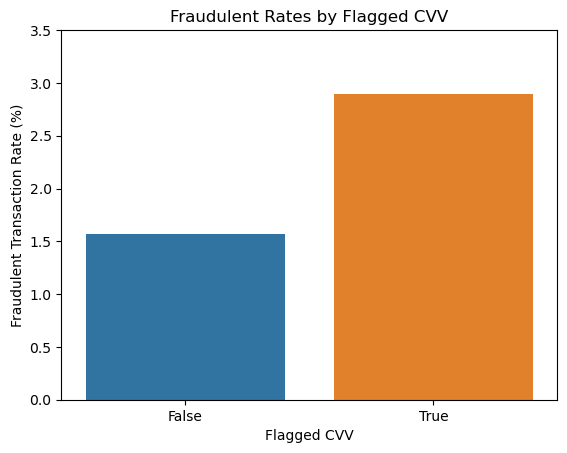

```python
data_by_flag1 = modified_data.groupby(bad_cvv)['isFraud'].agg([("isFraud", "mean"), ("count", "count")])
data_by_flag1['isFraud']*=100
# Barplot of Flagged CVV against isFraud
sns.barplot(x=data_by_flag1.index, y=data_by_flag1.isFraud)
plt.title('Fraudulent Rates by Flagged CVV')
plt.xlabel('Flagged CVV')
plt.ylabel('Fraudulent Transaction Rate (%)')
plt.ylim((0, 3.5))
plt.show()
```

So when a CVV entered disagrees with the actual CVV, the frequency of fraudulent transactions increase by 2-fold.

### Store Level Findings

- If a transaction amount at a merchant was flagged as fraudulent, then future transaction of the same amount and location should also be investigated for fraud
- Merchant stores have multiple franchises and numbers to identify the franchise. There is no trend over franchise IDs and difference in fraudulent transactions.

Merchant names in the data set have different merchant store numbers. We could include all these in the data set, however it may result in a large data set and is intractable to deal with. Instead, we check if we can drop the store numbers, by making sure the fraud rates across chains are not too different. This is an important step since we do not want to cluster stores numbers that have different fraud profiles.

#### i) If a transaction amount at a merchant was flagged as fraudulent, then future transaction of the same amount and location should also be investigated for fraud

Typically a fraudulent transaction made at merchant will target multiple people. Usually, the amount frauded is the same for everyone. If an account was flagged for fraud at a particular location, we would expect other transactions at the same merchant for the same amount to be fraudulent.

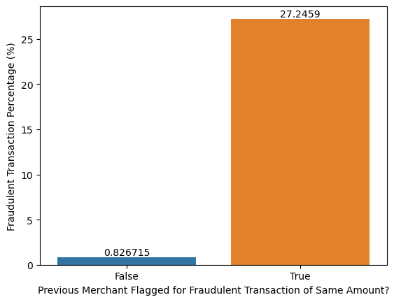

```python
# sort by transaction date, and group by amount and merchant
modified_data = modified_data.sort_values('transactionDateTime')
grouped_data = modified_data.groupby(['transactionAmount', 'merchantName'])

# denote if previous transaction was fraud
flag_previous_fraud = grouped_data['isFraud'].shift(1)

previous_fraud_df = modified_data.groupby(flag_previous_fraud)['isFraud']
previous_fraud_df = previous_fraud_df.agg([("isFraud", "mean"), ("count", "count")])
previous_fraud_df['isFraud'] = previous_fraud_df['isFraud'] * 100
modified_data['previous_fraud'] = flag_previous_fraud


ax = sns.barplot(x=previous_fraud_df.index, y=previous_fraud_df.isFraud, errwidth=0)
plt.xlabel('Previous Merchant Flagged for Fraudulent Transaction of Same Amount?')
plt.ylabel('Fraudulent Transaction Percentage (%)')
plt.bar_label(ax.containers[0])
plt.show()
```

The analysis suggests that transaction that occur at the same merchants of the same amount, that were previously flagged for fraud, has shown to indicate more frequent fraudulent activity, by about 30 times. We may try to include this into our fraud detection system.

#### ii) There is no trend over franchise IDs and difference in fraudulent transactions.

In otherwords, we expect franchises to have the same distribution of fraudulent transactions, over all their franchises.

```python
short_merch_name = modified_data['merchantName'].str.split('#').str.get(0).str.strip()
num_unique_stores = short_merch_name.nunique()
print(f"There are {num_unique_stores} unique stores.")
```

```
There are 205 unique stores.
```

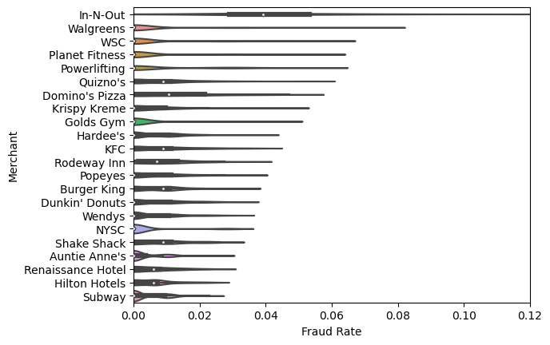

```python
short_merch_name.name = 'truncated_merchant'
merchant_name_grouped = modified_data.groupby([short_merch_name,data.merchantName])['isFraud']
merchant_name_grouped = pd.DataFrame(merchant_name_grouped.agg([("isFraud", "mean"), ("count", "count")]))
merchant_name_grouped = merchant_name_grouped.reset_index().sort_values(by='isFraud',ascending=False)

modified_data['truncated_merchant'] = short_merch_name

# for visualization purposes
large_num = (merchant_name_grouped.groupby('truncated_merchant')['isFraud'].count()>45)
large_num = merchant_name_grouped.loc[merchant_name_grouped['truncated_merchant'].isin(large_num.index[large_num])]

# create a scatterplot of the fraud rate for each subgroup within each group
ax = sns.violinplot(y=large_num['truncated_merchant'], x=large_num['isFraud'])
ax.set(xlabel='Fraud Rate', ylabel='Merchant')
ax.set_xlim(0, 0.12)
plt.show()
```

The merchants appear to have very similar distributions over the fraud rate. The vast majority of merchant franchises do not record any fraudulent activity and has a distribution clustered close 0. Thus we can consider aggregating them by pooling all the franchises branches to single groups. However we note that In-n-Out transactions tend to have a higher fraudulent transaction rate. This may be useful in our model.

# Feature Designing

## a) Reversed Transaction

In order to identify reversed transactions, we should reasonably expect the following:

1. The reverse transaction has the same amount as the original transaction
2. The reverse transaction should belong to the same account number and merchant name
3. The transaction type should be of type PURCHASE and then followed by a REVERSAL that happens after the purchase. The reversal does not need to be immediately after the purchase.

```python
modified_data = modified_data.sort_values(['accountNumber','transactionAmount','transactionDateTime'])

condition1 = (modified_data['transactionAmount'] == modified_data['transactionAmount'].shift(1))
condition2 = (modified_data['accountNumber'] == modified_data['accountNumber'].shift(1)) & (modified_data['merchantName'] == modified_data['merchantName'].shift(1))
condition3 = ((modified_data['transactionType'] == "REVERSAL") &
              (modified_data['transactionType'].shift(1) == "PURCHASE"))

reversed_condition = (condition1 & condition2 & condition3)
reversed_select = (reversed_condition | reversed_condition.shift(-1))
# select the rows that meet the condition and the rows that follow them
reversed_df = modified_data.loc[reversed_select]
```

The dataset above contains pairs of purchases and reversals. To calculate the total value of reversed transactions, the durations, and averages, we treat each purchase and reversal pair as a group.

We can efficiently group transactions and assign unique IDs to each group using cumsum(), which is a neat trick since we can avoid looping over the data set. We negate the boolean conditions defined above, and keep track of a cumulative sum that sums over increments when the above conditions are NOT met. Thus when the conditions are not met, we continue to increment, but when we hit a purchase/reversal group, the cumsum does not increment. This running sum can be treated as a group ID.

```python
transaction_group_r = (~(reversed_condition)).cumsum()

# sum of reversed transactions
value_of_reversed = reversed_df.groupby(transaction_group_r).apply(
    lambda x: x['transactionAmount'].iloc[1:].sum()).sum()

# total count of reversed transactions
num_reversed = reversed_df.groupby(transaction_group_r).apply(lambda x: len(x)-1).sum()

# avg of reversed
avg_value_reversed = value_of_reversed / num_reversed

# duration between purchase and reversal
avg_duration_seconds = reversed_df.groupby(transaction_group_r)['transactionDateTime']
avg_duration_seconds = avg_duration_seconds.diff().mean().total_seconds()
avg_duration_days = avg_duration_seconds // (24 * 3600)
avg_duration_hours = (avg_duration_seconds % (24 * 3600)) // 3600

print(f"The total dollar count of reversed transactions is: ${value_of_reversed}")
print(f"The total number of reversed transactions is: {num_reversed}")
print(f"The average transaction amount of reversed transactions is: ${round(avg_value_reversed, 2)}")
print(f"The average duration between reversed transaction pairs is: {int(avg_duration_days)} days, {int(avg_duration_hours)} hours")
```

```
The total dollar count of reversed transactions is: $2661859.55
The total number of reversed transactions is: 17704
The average transaction amount of reversed transactions is: $150.35
The average duration between reversed transaction pairs is: 10 days, 14 hours
```

```python
modified_data['reversed'] = reversed_select
```

## b) Multi-swipe Transactions

Multiswipe transactions are transactions that occur multiple times in a short time frame of the same amount. This may happen as a fraudulent transaction, or as a mistake where the merchant processes a payment multiple times on accident. We identify the criteria with the following heuristics:

1. The transaction amount has to be the same across adjacent transactions
2. The transactions should be the same amount
3. The transaction should happen in a short period of time, which we will say within 20 minutes.
4. The transaction has to be from the same merchant and account number
5. The transaction should be of type PURCHASE

```python
modified_data = modified_data.sort_values(['accountNumber','transactionDateTime'])

condition1 = (modified_data['transactionAmount'] == modified_data['transactionAmount'].shift(1))
condition2 = (modified_data['accountNumber'] == modified_data['accountNumber'].shift(1))
condition3 = (modified_data['merchantName'] == modified_data['merchantName'].shift(1))
condition4 = (modified_data['time_since_prev_transaction'] <= pd.Timedelta(seconds=1200))
condition5 = ((modified_data['transactionType'] == modified_data['transactionType'].shift(1)) &
              (modified_data['transactionType'] == "PURCHASE"))
multi_swipe_condition = condition1 & condition2 & condition3 & condition4 & condition5
multi_swipe_select = (multi_swipe_condition | multi_swipe_condition.shift(-1))
# select the rows that meet the condition and the rows that follow them
multi_swipe_df = modified_data.loc[multi_swipe_select]

transaction_group_ms = (~(multi_swipe_condition)).cumsum()

# Calculate the total dollar count of reversed transactions
total_dollar_count = multi_swipe_df.groupby(transaction_group_ms)
total_dollar_count = total_dollar_count.apply(lambda x: x['transactionAmount'].iloc[1:].sum()).sum()

# Calculate the total number of reversed transactions
total_num_multi_txns = multi_swipe_df.groupby(transaction_group_ms).apply(lambda x: len(x)-1).sum()

# Calculate the average transaction amount of reversed transactions
avg_multi_txn_amount = total_dollar_count / total_num_multi_txns

print(f"The total dollar count of multi-swipe transactions is: ${round(total_dollar_count, 2)}")
print(f"The total number of reversed transactions is: {total_num_multi_txns}")
print(f"The average transaction amount of reversed transactions is: ${round(avg_multi_txn_amount, 2)}")
```

```
The total dollar count of multi-swipe transactions is: $1085441.31
The total number of reversed transactions is: 7334
The average transaction amount of reversed transactions is: $148.0
```

## c) Interesting Findings

To connect these findings to the fraud problem, we hypothesize that reversals and multiswipes are more likely to be fraudulent.

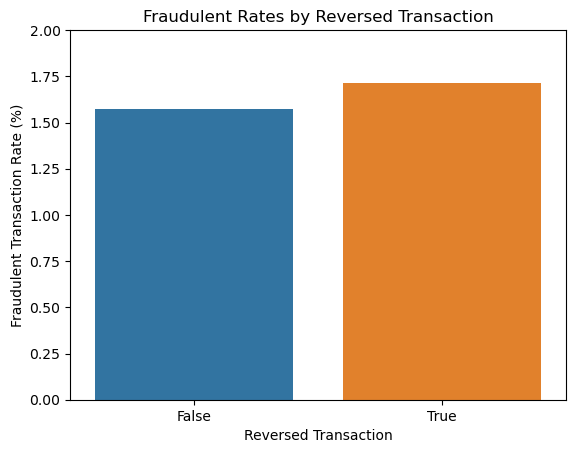

```python
by_reversals =  modified_data.groupby(reversed_select)['isFraud'].agg([("isFraud", "mean"), ("count", "count")])
by_reversals['isFraud']*=100
sns.barplot(x=by_reversals.index, y=by_reversals.isFraud)
plt.title('Fraudulent Rates by Reversed Transaction')
plt.xlabel('Reversed Transaction')
plt.ylabel('Fraudulent Transaction Rate (%)')
plt.ylim((0, 2))
plt.show()
```

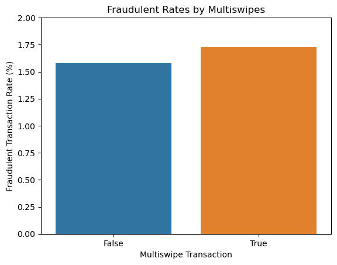

```python
by_multiswipe =  modified_data.groupby(multi_swipe_select)['isFraud'].agg([("isFraud", "mean"), ("count", "count")])
by_multiswipe['isFraud']*=100
sns.barplot(x=by_multiswipe.index, y=by_multiswipe.isFraud)
plt.title('Fraudulent Rates by Multiswipes')
plt.xlabel('Multiswipe Transaction')
plt.ylabel('Fraudulent Transaction Rate (%)')
plt.ylim((0, 2))
plt.show()
```

From these plots, we see that reversed and multiswipe transactions are more likely to be fraudulent, albeit the difference is small. Ultimately, we will not know if a transaction is reversed, or is a multiswipe, until after the second transaction, where it may be a reversal, or another purchase of the same amount. While these features can clearly provide features for a fraud detection model, it would rely on data from the future, and is not a measurable event until at least after the second transaction occurs. Thus we cannot add this to our model, or we would suffer from data leakage.

## d) Tying Up Loose Ends in Data Wrangling

We need to take extra care in examining if missing data in `posConditionCode`, `transactionType`, `merchantCountryCode`, and `posEntryMode` are related to fraudulent transactions. The absence of these data points can be valuable in determining what is fraudulent. That is, the absence of evidence is *not* the evidence of absence. Below, we compare:

```python
def get_mean_fraud_rate(data_name):
    missing = modified_data[data_name].isna()
    missing_mean = modified_data[missing]['isFraud'].mean()
    non_missing_mean = data[~missing]['isFraud'].mean()
    print(f"Mean fraud rate for missing {data_name}: {missing_mean:.2%}")
    print(f"Mean fraud rate for non-missing {data_name}: {non_missing_mean:.2%}")

get_mean_fraud_rate('posConditionCode')
get_mean_fraud_rate('transactionType')
get_mean_fraud_rate('merchantCountryCode')
get_mean_fraud_rate('posEntryMode')
```

```
Mean fraud rate for missing posConditionCode: 5.38%
Mean fraud rate for non-missing posConditionCode: 1.58%
Mean fraud rate for missing transactionType: 2.01%
Mean fraud rate for non-missing transactionType: 1.58%
Mean fraud rate for missing merchantCountryCode: 11.33%
Mean fraud rate for non-missing merchantCountryCode: 1.57%
Mean fraud rate for missing posEntryMode: 6.64%
Mean fraud rate for non-missing posEntryMode: 1.55%
```

Across the board, we observe that transactions that have missing values have a higher fraud rate than the transactions that do not have missing values. Thus we should create new features to handle these missing values. We call these values as 'Unknown', so that we know these values are unpopulated but meaningful.

```python
modified_data['posConditionCode'] = modified_data['posConditionCode'].fillna('Unknown')
modified_data['transactionType'] = modified_data['transactionType'].fillna('Unknown')
modified_data['merchantCountryCode'] = modified_data['merchantCountryCode'].fillna('Unknown')
modified_data['posEntryMode'] = modified_data['posEntryMode'].fillna('Unknown')
```

# Models

In order to pass factor variables into a model, we consider turning them into dummy variables, that will be treated as one-hot encoded variables. We do this for our categorical features. Additionally, some of our time variable still have missing values. We interpolate the missing values, and convert datetime objects into seconds.

```python
cat_cols =['merchantCountryCode','posEntryMode','posConditionCode','merchantCategoryCode','transactionType','truncated_merchant']
one_hot_df = pd.get_dummies(modified_data.loc[:, cat_cols], drop_first=True)
modeling_df = pd.concat([modified_data.drop(cat_cols, axis=1), one_hot_df], axis=1)

modeling_df['difference_moving_median'] = modeling_df['difference_moving_median'].interpolate()
modeling_df['time_since_prev_transaction'] = modeling_df['time_since_prev_transaction'].dt.total_seconds()/ (60*60*24)
modeling_df['time_until_next_transaction'] = modeling_df['time_until_next_transaction'].dt.total_seconds()/ (60*60*24)
modeling_df['time_since_prev_transaction'] = modeling_df['time_since_prev_transaction'].fillna(0)
modeling_df['time_until_next_transaction'] = modeling_df['time_until_next_transaction'].fillna(0)

modeling_df['previous_fraud'] = modeling_df['previous_fraud'].astype(bool)
```

Now we begin our train and test split. We split by account number, to ensure that all transactions beloning to a single account stay in the same side of the split to prevent data leakage. As we have discovered that the response variable `isFraud` is highly imbalanced, we should think of a way to handle the class imbalance so as to not bias the model towards rating everything as not fraudulent. Parallel to this, we also need to think about the speed and computational tractability of modelling. With over 700,000 data points, only about 11,000 data points are fraudulent. One way to handle the computational tractability issue, while also reducing the class imbalance, is to undersample.

```python
train_accounts, test_accounts = train_test_split(modeling_df['accountNumber'].unique(), test_size=0.3, random_state=42)
train_data = modeling_df[modeling_df['accountNumber'].isin(train_accounts)]
test_data = modeling_df[modeling_df['accountNumber'].isin(test_accounts)]

X_train = train_data.drop(['isFraud','accountNumber','transactionDateTime',
                           'merchantName', 'currentExpDate', 'accountOpenDate',
                           'dateOfLastAddressChange', 'enteredCVV', 'cardCVV',
                           'cardLast4Digits'], axis=1)
y_train = train_data['isFraud']

X_test = test_data.drop(['isFraud','accountNumber','transactionDateTime',
                         'merchantName', 'currentExpDate', 'accountOpenDate',
                         'dateOfLastAddressChange', 'enteredCVV', 'cardCVV',
                         'cardLast4Digits'], axis=1)
y_test = test_data['isFraud']

sampler = RandomUnderSampler(random_state=0x0badbeef)
X_sampled, y_sampled = sampler.fit_resample(X_train, y_train)
```

## Models Evaluated

We evaluate three models, Random Forest, XGBoost, and Gradient Boosting. These three models are some of the most popular, in part due to their simplicity and overall success in general supervised learning tasks.

- Random Forest: A popular model in fraud detection since it handles non-linearities in a non-parametric fashion, as well as being resistent to overfitting. A random forest is constructed by training a large number of decision trees on randomly sampled subsets of predictors. Each tree produces a prediction and is averaged over all the trees to make a final prediction. This is a bagging type of classifier.
- Gradient Boosting: This is another popular model that uses a boosting approach, as opposed to bagging like in random forests. The boosting approach starts with a weak classifier iteratively fits further trees to fit the residuals of the previous weaker classifier. This nature of training can be susceptible to overfitting, so we must consider using k-fold CV and picking optimal hyperparameters.
- XGBoost: One way to combad the overfitting issue in Gradient Boosting is by regularization. XGBoost handles this with L2 regularization, where it discourages the weights in the model from growing too large. This can combat overfitting, since typically, overfitting is a product of a highly non-smooth parameter space, with certain parameters being large in value, learned from memorizing the data. The regularization term prevents this from happening by discouranging any one weight from becoming too large. This algorithm is also faster than gradient boosting.

As a final step, we ensemble these models. This allows us to leverage the benefits of the models above, while dampening the effects of each model's negative qualities.

## Metric to Evaluate

We are trying to detect fraud. Ideally, we wish to be able to identify fraud 100% of the time, however this expectation is not realistic. Instead we must decide which type of mistakes our model makes, is more costly. If our model fails to identify fraud, when the transaction was actually fraudulent, as an organization, we may suffer damages and develop a bad reputation. This is worse than being overly cautious and potentially flagging legitimate transactions as fraudulent. Thus we choose to optimize to minimize false negatives, or maximize recall. Models with high recall are better at detecting fraud, when there in fact is fraud. Recall effectively measures the power, in the statistical sense, of a classifer.

Regarding hyperparameter tuning, we use Grid Search, to optimize for recall. We do not tune `n_estimators` since literature in predictive analytics suggests we should always use as many estimators are possible, provided the computational power can handle the load. Here, we use 200 estimators for all the models.

```python
models = {
    'XGBoost': XGBClassifier(),
    'Random Forest': RandomForestClassifier(),
    'Gradient Boosting': GradientBoostingClassifier()
}

parameters = {
    'XGBoost':  {'n_estimators': [200],'learning_rate': [0.01, 0.1, 1.0]},
    'Random Forest': {'n_estimators': [200], 'max_depth': [5, 10, 20]},
    'Gradient Boosting': {'n_estimators': [200], 'learning_rate': [0.01, 0.1, 1.0]}
}

# Train and evaluate each model using k-fold cross-validation and hyperparameter tuning
cv = 5
results = {}
best_models = {}
for name, model in models.items():
    param_grid = parameters[name]
    grid_search = GridSearchCV(model, param_grid, cv=cv, scoring='recall')
    grid_search.fit(X_sampled, y_sampled)
    results[name] = grid_search.best_score_
    best_models[name] = grid_search.best_estimator_

    print("Best recall score for {}:".format(name), results[name])
    print("Best model for {}:".format(name), best_models[name])
```

```
Best recall score for XGBoost: 0.7768033518937096
Best model for XGBoost: XGBClassifier(base_score=None, booster=None, callbacks=None,
              colsample_bylevel=None, colsample_bynode=None,
              colsample_bytree=None, early_stopping_rounds=None,
              enable_categorical=False, eval_metric=None, feature_types=None,
              gamma=None, gpu_id=None, grow_policy=None, importance_type=None,
              interaction_constraints=None, learning_rate=0.01, max_bin=None,
              max_cat_threshold=None, max_cat_to_onehot=None,
              max_delta_step=None, max_depth=None, max_leaves=None,
              min_child_weight=None, missing=nan, monotone_constraints=None,
              n_estimators=200, n_jobs=None, num_parallel_tree=None,
              predictor=None, random_state=None, ...)
Best recall score for Random Forest: 0.728428616057482
Best model for Random Forest: RandomForestClassifier(max_depth=10, n_estimators=200)
Best recall score for Gradient Boosting: 0.8194682544057923
Best model for Gradient Boosting: GradientBoostingClassifier(learning_rate=0.01, n_estimators=200)
```

```python
model_rf = RandomForestClassifier(n_estimators=200,max_depth=5)
model_gb = GradientBoostingClassifier(n_estimators=200,learning_rate=0.01)
model_xgb = XGBClassifier(objective = 'binary:logistic',n_estimators = 200, learning_rate= 0.01)
ensemble_model = VotingClassifier(estimators=[('rf',model_rf),
                                              ('gb',model_gb),
                                              ('xgb',model_xgb)], voting='soft')
ensemble_model.fit(X_sampled, y_sampled)
```

```
VotingClassifier(estimators=[('rf',
                              RandomForestClassifier(max_depth=5,
                                                     n_estimators=200)),
                             ('gb',
                              GradientBoostingClassifier(learning_rate=0.01,
                                                         n_estimators=200)),
                             ('xgb',
                              XGBClassifier(base_score=None, booster=None,
                                            callbacks=None,
                                            colsample_bylevel=None,
                                            colsample_bynode=None,
                                            colsample_bytree=None,
                                            early_stopping_rounds=None,
                                            enable_categorical=False,
                                            eval_m...
                                            gpu_id=None, grow_policy=None,
                                            importance_type=None,
                                            interaction_constraints=None,
                                            learning_rate=0.01, max_bin=None,
                                            max_cat_threshold=None,
                                            max_cat_to_onehot=None,
                                            max_delta_step=None, max_depth=None,
                                            max_leaves=None,
                                            min_child_weight=None, missing=nan,
                                            monotone_constraints=None,
                                            n_estimators=200, n_jobs=None,
                                            num_parallel_tree=None,
                                            predictor=None, random_state=None, ...))],
                 voting='soft')
```

```python
# define the models to evaluate
models = [
    ('Random Forest', model_rf),
    ('Gradient Boosting', model_gb),
    ('XGBoost', model_xgb),
    ('Ensemble model', ensemble_model)
]

# define the cross-validation method
cv = KFold(n_splits=5, shuffle=True, random_state=42)

# define the metrics to evaluate
scoring = {
    'accuracy': 'accuracy',
    'recall': 'recall',
    'precision': 'precision',
    'f1': 'f1',
    'roc_auc': 'roc_auc'
}

# evaluate each model using cross-validation and store the results
results = {}
for name, model in models:
    cv_results = cross_validate(model, X_sampled, y_sampled, cv=cv, scoring=scoring, return_train_score=True)
    results[name] = cv_results

    # Print the confusion matrix
    y_pred = cross_val_predict(model, X_sampled, y_sampled, cv=cv)
    cm = confusion_matrix(y_sampled, y_pred)
    print(name + ' confusion matrix:')
    print(cm)
```

```
Random Forest confusion matrix:
[[6169 2079]
 [1462 6786]]
Gradient Boosting confusion matrix:
[[6186 2062]
 [1307 6941]]
XGBoost confusion matrix:
[[6281 1967]
 [1233 7015]]
Ensemble model confusion matrix:
[[6250 1998]
 [1209 7039]]
```

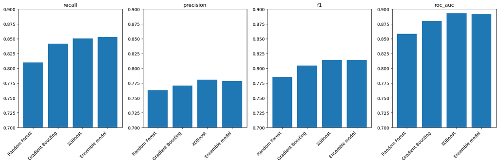

```
Random Forest
accuracy (train): 0.7867816906958219
accuracy (test): 0.7793399652787346
recall (train): 0.819204671814405
recall (test): 0.8099559608877378
precision (train): 0.7692882447581144
precision (test): 0.7633237643814612
f1 (train): 0.7934008197676847
f1 (test): 0.7856669192732684
roc_auc (train): 0.867267962395133
roc_auc (test): 0.8579567708312552

Gradient Boosting
accuracy (train): 0.8002394428469108
accuracy (test): 0.795767973766155
recall (train): 0.8465884618031699
recall (test): 0.8415724314293733
precision (train): 0.7747868862598514
precision (test): 0.7709499439221468
f1 (train): 0.8090812659261891
f1 (test): 0.8046537894494984
roc_auc (train): 0.885540908717943
roc_auc (test): 0.8802081277036106

XGBoost
accuracy (train): 0.8215324790098183
accuracy (test): 0.8060132271487228
recall (train): 0.8674819676482224
recall (test): 0.8505427302279707
precision (train): 0.7944858061624627
precision (test): 0.7810055437562266
f1 (train): 0.8293698397150837
f1 (test): 0.8142345366545707
roc_auc (train): 0.9096129625874501
roc_auc (test): 0.8927425782260796

Ensemble model
accuracy (train): 0.8149854193808871
accuracy (test): 0.805346229803338
recall (train): 0.8631435128563053
recall (test): 0.8528335099875065
precision (train): 0.7873230925321539
precision (test): 0.7788463871893828
f1 (train): 0.8234815757545888
f1 (test): 0.8141175405044165
roc_auc (train): 0.9025119057737581
roc_auc (test): 0.8914670348271654
```

```python
# plot the results for each metric
fig, axs = plt.subplots(ncols=4, figsize=(20,5))
metrics = ['recall', 'precision', 'f1', 'roc_auc']
for i, metric in enumerate(metrics):
    axs[i].bar(results.keys(), [results[model]['test_'+metric].mean() for model in results.keys()])
    axs[i].set_title(metric)
    axs[i].set_ylim((0.7, 0.9))
    plt.setp(axs[i].xaxis.get_majorticklabels(), rotation=45, ha='right')
plt.show()

# print the results for each model and metric
for name, model in models:
    print(name)
    for metric in scoring.keys():
        print(metric + ' (train):', results[name]['train_'+metric].mean())
        print(metric + ' (test):', results[name]['test_'+metric].mean())
    print()
```

From the model results, all models very well, with recall scores greater than 80%. Overall, we do not see any issues with overfitting, as the train and test metrics are about the same across the models. XGBoost and the ensemble model have the highest overall performance across all metrics when evaluated on the test set, which the model has not seen before.

As XGBoost and the ensemble model have similar recall scores, I would recommend use of the XGBoost model, since it is smaller in size than the ensemble method. XGBoost is a part of the ensemble, and the addition of random forest and gradient boosting in the ensemble yields marginal benefits.

## Feature Importances

Having selected XGBoost as the preferred model, we can determine its feature importances. By analyzing feature importance, we can uncover the key relationships that influence the model's predictions. This knowledge not only enhances our understanding of the problem but also informs future data collection and feature engineering strategies.

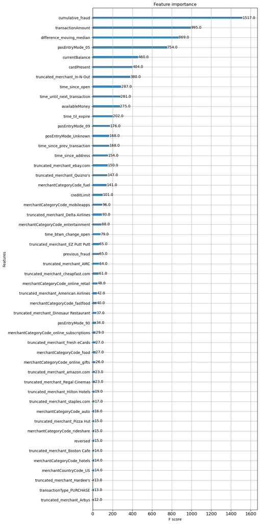

```python
model_xgb.fit(X_sampled, y_sampled)
fig, ax = plt.subplots(figsize=(10,20))
plot_importance(model_xgb, ax=ax, max_num_features=50)
ax.tick_params(axis='x', labelsize=12)
plt.tight_layout()
plt.show()
```

8 of our engineered features turned out to be in the top 20 most important features. The top 3 most important features are:

- `cumulative_fraud`: How many transactions has this account had, that have been flagged before?
- `transactionAmount`: the amount of the transaction
- `difference_moving_median`: If a transaction amount is significantly different from its previous transaction amounts

Two of these three features are products of our feature engineering.

The feature `posEntryMode_05` is also important. This finding can drive future modifications in protocol to help curb fraudulent activity in these types of points of sale.

# Future Directions

In practice, I would spend more time tuning the models above, using a train set which is to be partitioned into a train and validation set. This would take more time but reduce further risks of data leakage. In the current method, we suffer some data leakage due to cross validation occuring on future data sets. This happens because in k-fold CV, we might train based on future transactions to evaluate the hold out set containing transaction that occured in the past. To solve this problem, we would consider implementing a time series cross validation.

Some alternative methods that have been proven to work in other domains are network analytics, and reinforcement learning. Both methods approach the problem in a different manner, and addresses a critical flaw in classical predictive analytics: time and data dependencies.

## Network Analysis

Merchants and customers transactions can be represented as a bipartite network, where transactions are edges, and edges connect merchants to customers. We can perform edge classification to determine whether or not a transaction is fraudulent. Due to the nature of network data, this method allows us to identify accounts or merchants that are at the center of fraudulent transactions. The steps for this type of analysis are as follows:

- Define each node as either a merchant or an account. Draw an edge if a transaction has occured between them, and weight it by the number of transactions
- Measure centrality metrics to identify "popular" merchants. We can perform several data explorations at this point
- Encode the network and perform supervised learning on the network

## Reinforcement Learning.

Additionally, we can approach this problem from a reinforcement learning perspective. The benefits of this method allow for online experimentation, wherein each new data point trains the model, and we do not need to rely on a hold out test set to evaluate our model. In particular, Q-learning allows us to consider time dependencies, which is a big drawback to current predictive analytics methods, where there are IID assumptions in the models. The steps of this type of analysis are as follows:

- Define an agent to take in transaction data i.e. accountId, merchantName, other features we engineered in the project, and provide an action (fraud, not fraud)
- Sort the transaction data by increasing order of time
- As the agent iteratively moves down the transaction data, it updates its probabilities of taking a particular action through the classical Q learning algorithm

These methods could potentially yield better results and better generalizability than the predictive analyics approach we detailed in this project.